# BIS180L Midterm

**Spring, 2015**  
**Available May 1, 2015**  
**Due May 7, 1:10 PM**

**60 points total**

**Student Name:**

**Student ID:**

# Limitations

This exam is open book, open notes, open web **HOWEVER** You CANNOT discuss the questions with any person or entity.  
You CANNOT request help from any person, online forum, listserv, chatroom, or other entity, etc.

You CAN ask Kristen or Professor Maloof for help or clarification.

# Instructions

1. Work by adding your answers to this .Rmd file
2. For all questions provide any code that you used to answer them formatted as a code block.
3. For the R questions the code should run and embed the answers when you knit this file.
4. When you are ready to turn in the exam, knit an html file, add both the .Rmd an the .html file and push to your repository. You do not need to turn in a PDF.

## Question 0 (2 points)

Throughout this assignment, you code should have helpful comments and appropriate variable names.

1 pt for helpful comments  
1 pt for appropriate variable names

## Question 1 (16 points)

Your professor has entered into a contract with a biotech company to study a secret gene and puts you on the project. The company will not reveal the identity of the gene or even the source organism.

Being the curious scientist that you are, you decide to ignore the consequences (lawsuits) and to sequence it. The sequence is available in the file “Mystery1.fa”

You hypothesize that the sequence has come from a model organism.

**a.** Did the gene come from *Arabidopsis*, *C. elegans*, *Drosophila* or some other organism? If you think it came from some other organism is that organism likely a plant or animal? Explain the reasoning behind your conclusion.

BLAST example. Smith-Waterman would have been OK also

```
#format database (not necessary for full credit)
xdformat -p ~/Day2/Data/Sequences/Proteome/A.thaliana.fa
xdformat -p ~/Day2/Data/Sequences/Proteome/C.elegans.fa
xdformat -p ~/Day2/Data/Sequences/Proteome/D.melanogaster.fa

#run blast
blastp ~/Day2/Data/Sequences/Proteome/A.thaliana.fa Mystery1.fa > A.thaliana_Mystery.blast.out
blastp ~/Day2/Data/Sequences/Proteome/C.elegans.fa Mystery1.fa > C.elegans_Mystery.blast.out
blastp ~/Day2/Data/Sequences/Proteome/D.melanogaster.fa Mystery1.fa > D.melanogaster_Mystery.blast.out
```

The gene most likely came from a plant, but not from Arabidopsis. It had a much stronger hit with Arabidopsis than with the other organisms, suggesting that it is a plant gene. However the percent identity with Arabidopsis was only 80%; I would expect a near-perfect match if this was actually an Arabidospis protein.

1 pt for species  
1 pt for binary plant or animal  
1 pt code  
2 pts explanation

**b.** List the best protein match for each organism (if there is one). Are these matches significant? How did you decide signficance?

| Organsism | Best Match | P-Value | % ID |
| --- | --- | --- | --- |
| *A. thaliana* | AT4G08920.1 | 0 | 80 |
| *C. elegans* | CE42669 | 0.56 | 24 |
| *D. Melanogaster* | FBpp0080934 | 2.3e-39 | 28 |
| —————— | ————- | ——— | —— |

Based on the p-value and using a cutoff of 0.05, The matches in *A. thaliana* and *D. melanogaster* are signficant whereas the *C. elegans* hit is not.

3 pt 1 for each organism  
1 pt significance explanation

**c.** For each organism do you think there is a single orthlog? Why or why not?

For Arabidopsis there appears to be a single orthlog because the next best match has a much less signficant p-value and a lower percent identity. In Drosophila at first glance it appears that there are four paralogs that match equally well but these turn out to be isoforms of the same protein. Answers for 1 or 4 orthologs in Drosophila accepted as correct. In C. elegans there appear to be no orthologs.

1 single ortholog  
1 explanation

**d.** Which program did you use to answer this question? Why? What advantages and disadvantages does it have over other choices?

I used blastp because it is faster and provides a p-value without needing to create a shuffled sequence. Those reasons also list its advantages. Disadvantages, relative to Smith-Waterman is that it is not guaranteed to return the best possible alignment.

1 pt listing program  
1 pt explanation  
1 pt advantage  
1 pt disadvantage

## Question 2 (6 points)

**a.** Unpack the `test.tar.gz` tarball

```
tar -xvzf test.tar.gz
```

1 pt code

**b.** The for loop below is meant to print the contents of each `test` file, but it doesn’t work. Fix it so that it runs.

#### Old

```
testFiles=`ls test*.txt`

for file in testFiles
    do
        cat $file
    done
```

#### New

```
testFiles=`ls test*.txt`

for file in $testFiles
    do
        cat $file
    done
```

1 pt new code  
1 pt correct bug fix

**c.** If the first line in part b is written as:

```
testFiles=`ls test*`
```

Will this also work the same way? Why or why not? Which version preferred?

No this does not work as well because it includes the gzipped file. The original version is preferred.

1 pt yes or no same way  
1 pt explanation  
1 pt explanation preferred version

## Question 3 (4 points)

The EMBOSS suite contains a program called `preg` that lets you search for protein patterns using regular expressions. Suppose you want to find how how often `IAN` occurs in the worm proteome. You would type

```
preg -sequence wormpep -pattern "IAN" -outfile out
```

The pattern below matches C2H2 Zn-finger proteins.

```
C.{2,4}C.{3}[LIVMFYWC].{8}H.{3,5}H
```

**a.** How many fly proteins have this pattern?

```
ln -s ../Assignment_2/flypep ./
preg -sequence flypep "C.{2,4}C.{3}[LIVMFYWC].{8}H.{3,5}H" -outfile zn.out
more zn.out
grep -c "Sequence:" zn.out
```

There are 738 proteins with this pattern

1 pt code  
1 pt answer

**b.** What is the average number of Zn-fingers per protein?

There are a lot of ways to solve this. I count the number of occurences of the pattern “regex:” which occurs with every hit. Once this is done then we can just divide this number by the total number of proteins with a hit

```
grep -c "regex:" zn.out
```

The total number of hits is 3334, so the average number is 3334/738 = 4.5 hits per protein.

1 pt code  
1 pt answer

(Some people answered this is avergae number of hits across all proteins in the proteome. While that is not what I intended with the question I give fill credit for that answer as well).

## Question 4 (6 points)

Perform the same Zn-finger search against the shuffled fly proteome.

**a.** How many proteins have this pattern, and what is the average number of Zn-fingers per protein?

```
 shuffleseq flypep flypep.shuffle.fa
 preg -sequence flypep.shuffle.fa "C.{2,4}C.{3}[LIVMFYWC].{8}H.{3,5}H" -outfile zn.shuffle.out
 more zn.shuffle.out
 grep -c "Sequence:" zn.shuffle.out
 grep -c "regex:" zn.shuffle.out
```

1 pt shuffle code  
1 pt calculation code  
1 pt # proteins  
1 pt average Zn-fingers

**b.** Explain why you think the shuffled sequence is similar/different from the real sequence with respect to the C2H2 Zn-finger pattern.

There are many fewer hits and many fewer hits per protein in the shuffled sequence. This indicates that the Zn Finger pattern occurs more often than expected by chance in the real proteome, suggesting that the motif has some function.

2 pt explanation

## Question 5 (5 points)

**a.** Describe three advantages to using a version control system like Git. 3 pt 1 for each advantage

1. Collaboration. It allows easy collaboration between different researchers.
2. Reproducibility. By storing code in a repository it enables other researchers to reproduce what has been done.
3. Documentatinon. By tracking changes we know how the code has evolved.
4. backup. If I make a change that messes something up it is easy to go back.

**b.** Describe two things that you can do to make your code more reproducible and understandable. 2 pt 1 for each thing

1. Good commenting
2. Logical variable names
3. Use a version control system.

## Question 6 (4 points)

The file “fms.csv” contains a subset of data from a study examining determinants of muscle size and response to training in college students. * The first row contains column headers. * The first column “id” is the subject number of the individual being studied * Each row represents the data from one person * Columns 2 through 226 contain SNP genotypes in a number of candidate genes * Columns 227 - 232 Contain information about the individual being studied. Of note * `Gender` * `Age` * `Race` * The remaining columns are various physiological parameters. Of note: * `NDRM.CH` : Percent change in muscle mass in the non-dominant arm * `DRM.CH` : Percent change in muscle mass in the dominant arm.

**a.** Load the file into R

```r
data <- read.csv("fms.csv.gz")
```

1 pt code

**b.** Create a plot to examine the relationship between gender and change in muscle mass in the non-dominant arm.

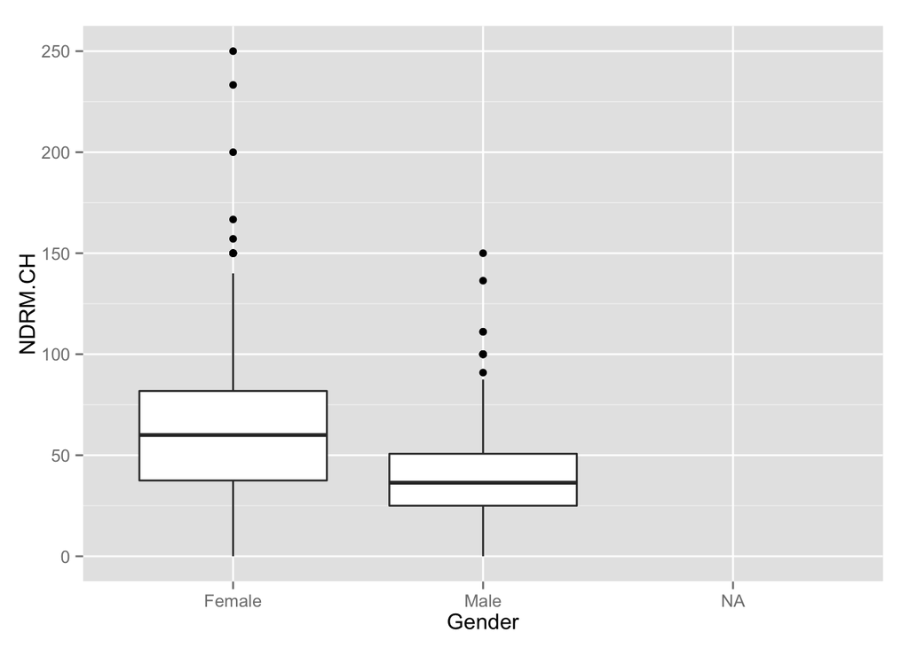

```r
library(ggplot2)
pl <- ggplot(data,aes(x=Gender,y=NDRM.CH))
pl <- pl + geom_boxplot()
pl
```

1 pt plot presence  
1 pt axes labeled  
1 pt accurate use of # by factors

## Question 7 (6 points)

**a.** What is the mean change in muscle mass in the non-dominant arm for each gender?

```r
tapply(data$NDRM.CH,data$Gender,mean,na.rm=T)
```

```
##   Female     Male
## 62.38897 40.00652
```

1 pt code  
2 pt 1 for each accurate mean

**b.** Does gender have a *significant* effect on change in muscle mass in the non-dominant arm? How do you know?

```r
summary(aov(data$NDRM.CH ~ data$Gender))
```

```
##              Df Sum Sq Mean Sq F value Pr(>F)
## data$Gender   1 107699  107699   114.1 <2e-16 ***
## Residuals   883 833705     944
## ---
## Signif. codes:  0 '***' 0.001 '**' 0.01 '*' 0.05 '.' 0.1 ' ' 1
## 187 observations deleted due to missingness
```

```r
#OR

t.test(data$NDRM.CH ~ data$Gender)
```

```
##
##  Welch Two Sample t-test
##
## data:  data$NDRM.CH by data$Gender
## t = 11.4935, df = 870.405, p-value < 2.2e-16
## alternative hypothesis: true difference in means is not equal to 0
## 95 percent confidence interval:
##  18.56029 26.20462
## sample estimates:
## mean in group Female   mean in group Male
##             62.38897             40.00652
```

Yes, Gender has a highly signiificant effect on the change in muscle mass. This is clear because the p-value for the Gender effect via ANOVA is < 2e -16.

1 pt test for significance  
2 pts explanation

## Question 8 (11 points)

**a.** Make and interpret an MDS plot to examine the relationship between ethnicity and population structure.

```r
geno.numeric <- data.matrix(data[,2:226]) # take the genotypes and the convert them to numeric
head(geno.numeric[,1:10]) #compare numeric to original
```

```
##      acdc_rs1501299 ace_id actn3_r577x actn3_rs540874 actn3_rs1815739
## [1,]              2      1           1              3               1
## [2,]              2      2           2              2               2
## [3,]              2      2           2              2               2
## [4,]              3      1           2              2               2
## [5,]              2      2           1              3               1
## [6,]              3      2           2              2               2
##      actn3_1671064 ardb1_1801253 adrb2_1042713 adrb2_1042714
## [1,]             1            NA             3             2
## [2,]             2            NA             3             1
## [3,]             2            NA             3             2
## [4,]             2            NA             1             1
## [5,]             1            NA             3             2
## [6,]             2            NA             3             2
##      adrb2_rs1042718
## [1,]               3
## [2,]               2
## [3,]               3
## [4,]               3
## [5,]               3
## [6,]               3
```

```r
head(data[,2:11]) #looks good
```

```
##   acdc_rs1501299 ace_id actn3_r577x actn3_rs540874 actn3_rs1815739
## 1             CA     DD          CC             GG              CC
## 2             CA     ID          CT             GA              TC
## 3             CA     ID          CT             GA              TC
## 4             CC     DD          CT             GA              TC
## 5             CA     ID          CC             GG              CC
## 6             CC     ID          CT             GA              TC
##   actn3_1671064 ardb1_1801253 adrb2_1042713 adrb2_1042714 adrb2_rs1042718
## 1            AA          <NA>            GA            CG              CC
## 2            GA          <NA>            GA            CC              CA
## 3            GA          <NA>            GA            CG              CC
## 4            GA          <NA>            AA            CC              CC
## 5            AA          <NA>            GA            CG              CC
## 6            GA          <NA>            GA            CG              CC
```

```r
#calculate euclidian distance
genDist <- as.matrix(dist(geno.numeric))

#perform the multi-dimensional scaling
geno.mds <- as.data.frame(cmdscale(genDist))
head(geno.mds) #now we have 2 dimensions
```

```
##           V1          V2
## 1  2.5759008 -1.33979530
## 2 -2.1028657 -0.06159522
## 3 -2.8941535 -0.06313048
## 4 -1.2734878  0.70144326
## 5  0.3187243 -2.00467756
## 6  0.3647236  0.12674212
```

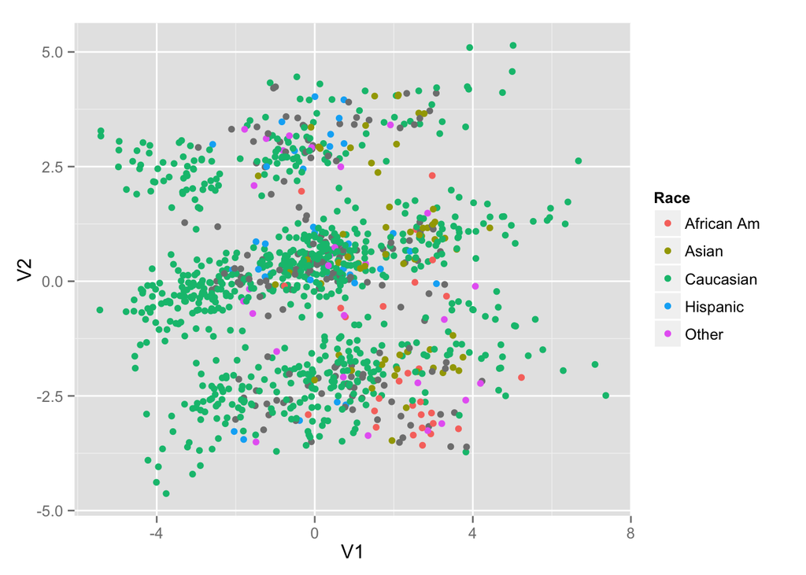

```r
data <- cbind(data,geno.mds)

qplot(V1,V2,data=data,color = Race, geom = "point")
```

The plot suggests that there is stratification, splitting the population into 3 different subgroups. Howver, there does not seem to be a strong relationship between supbgroup and ethnicity.

1 pt plot presence  
1 pt axis labels  
1 pt plot accuracy  
2 pt interpretation

**b.** How many potential population groups do you see?

Three subgroups.

1 pt answer within range

**c.** Is there an obvious correspondence with ethnicity? How do you know? Show your code.

(Already answered above), but, no I do not see an obvious correspondance between ethnicity and race.

1 pt yes or no  
1 pt code presence (really for the plot in part a)  
1 pt code accuracy (dito) 2 pt explanation